# STSCI 5065 - Lecture 15

Introduction to Apache Pig - Part 3: Pig Functions

Harry Lu

# 1 Pig Functions

- The built-in functions.
- User defined functions (UDFs).

# 2 Pig Built-in Functions

- Pig built-in functions can be used directly. These include load, store, filter and many other functions that we already saw.
- Two main properties differentiate built-in functions from user defined functions (UDFs).
  - First, built-in functions don’t need to be **registered** because Pig knows where they are.
  - Second, built-in functions don’t need to be **qualified** when they are used because Pig knows where to find them and what they are.
- For a list of these functions, see a file, named **Pig_Builtin_Functions.pdf**, on the course website.

# 3 Some Example of Pig Built-in Functions

## 3.1 `AVG()` Function

- The dataset: students GPA data of different terms.

  ```
  John Smith, fall 2000, 3.9
  John Smith, winter 2000, 3.8
  John Smith, spring 2001, 4.0
  John Smith, summer 2001, 3.9
  Mary Clark, fall 2000, 3.5
  Mary Clark, winter 2000, 3.0
  Mary Clark, spring 2001, 3.8
  Mary Clark, summer 2001, 3.9
  ```

- Calculate the average GPA of each student.

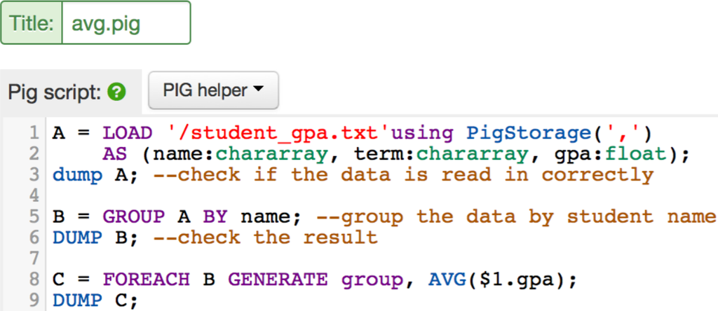

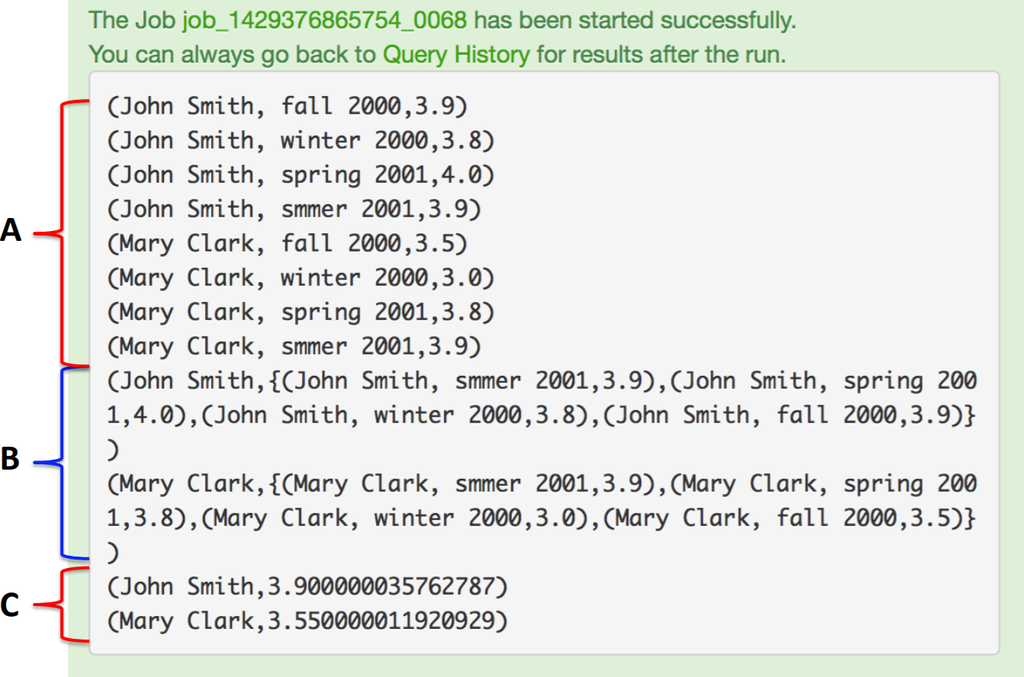

## 3.2 `ROUND_TO()` Function

- Returns the value of an expression rounded to a fixed number of decimal digits. Note that this function is different from the `ROUND()` function, which returns the value of an expression rounded to an integer.
- The syntax:

  ```
  ROUND_TO(val, digits)
  ```

- `val`: an expression whose result is type float or double: the value to round.
- `digits`: an expression whose result is type int: the number of digits to preserve.
- `mode`: an optional int specifying the rounding mode, according to the constants Java provides.

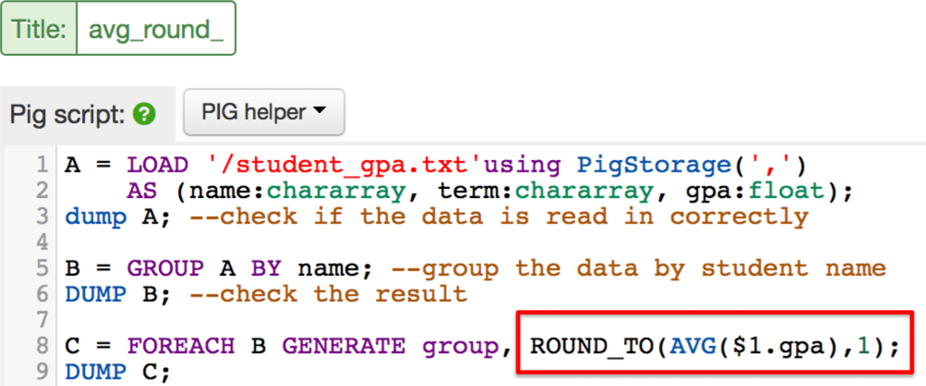

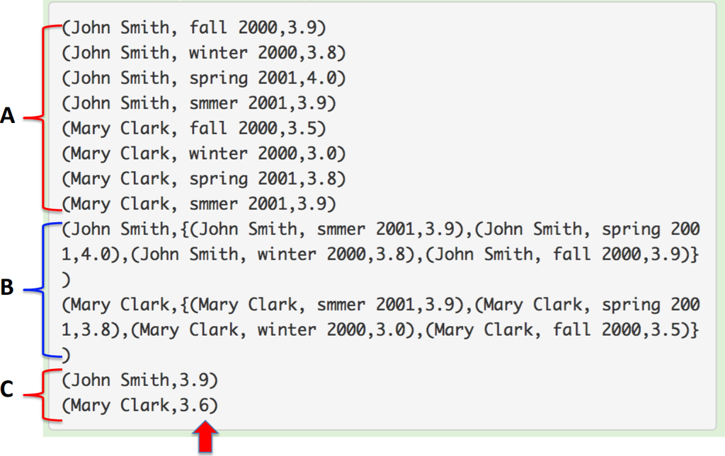

## 3.3 `MAX()` and `MIN()` Functions

- Computes the maximum or minimum of the numeric values or chararrays in a single-column bag. `MAX()` or `MIN()` requires a preceding `GROUP ALL` statement for global maximums or minimums and a `GROUP BY` statement for group maximums or minimums.

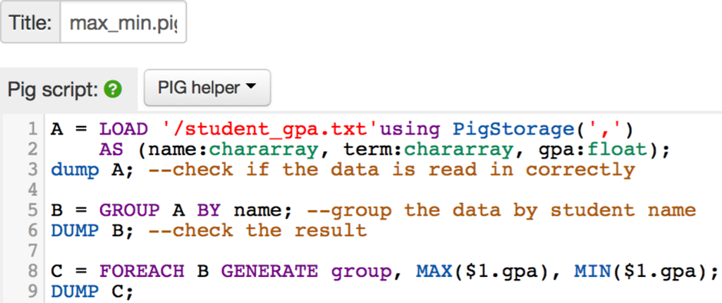

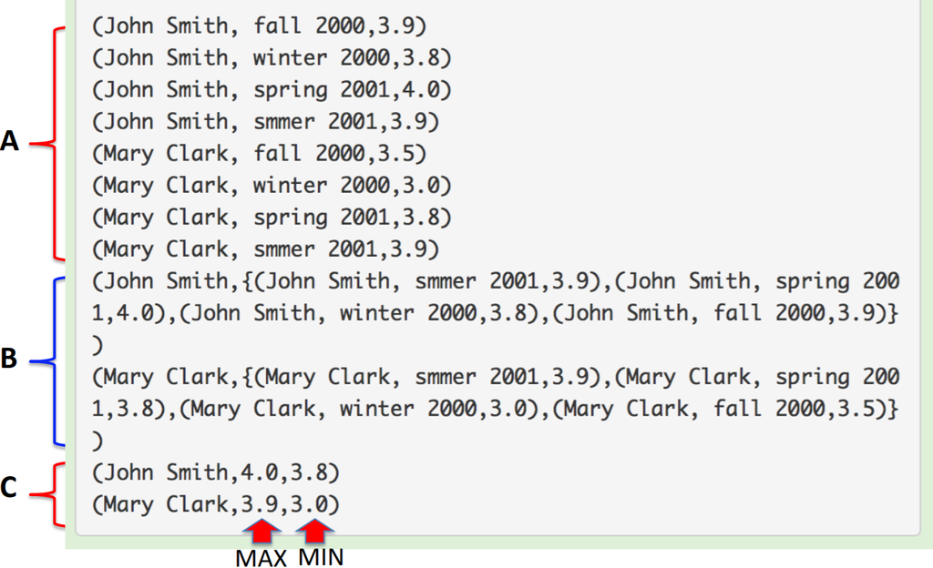

## 3.4 `SUBTRACT()` Functions

- `SUBTRACT()` takes two bags as arguments and returns a new bag composed of the tuples of first bag are that not in the second bag.
- The implementation assumes that both bags being passed to the `SUBTRACT()` function will fit **entirely into memory** simultaneously; if this is not the case, it will still function but will be very slow.
- Find out the bag elements that are in the first bag but not in the second bag:

  ```
  ({(8,9),(0,1),(1,2)},{(8,9),(1,1)})
  ({(2,3),(4,5)},{(2,3),(4,5)})
  ({(3,7),(3,7)},{(2,2),(3,7)})
  ({(1,2),(3,4),(5,6),(7,8)},{(2,3),(1,2)})
  ```

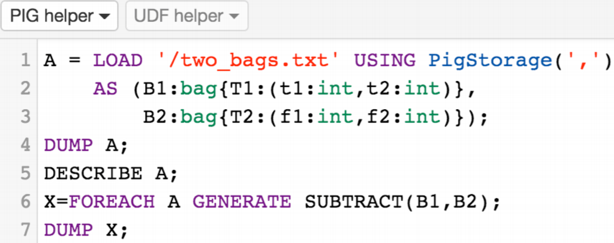

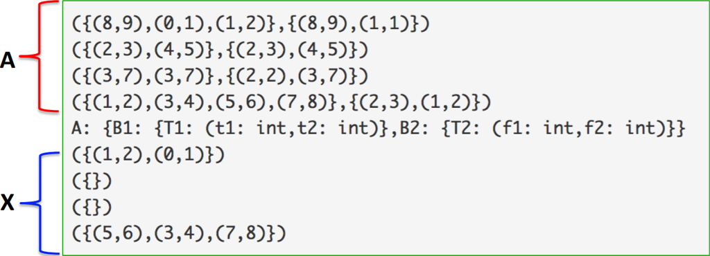

## 3.5 `ENDSWITH()` and `STARTSWITH()` Functions

- Tests inputs to determine if the first argument ends or starts with the string in the second argument. Returns `true` or `false`.
- Syntax:

  ```
  ENDSWITH(string, testAgainst)
  STARTSWITH(string, testAgainst)
  ```

- Examples:

  ```
  ENDSWITH ('foobar', 'foo') --> false
  ENDSWITH ('foobar', 'bar') --> true
  STARTSWITH ('foobar', 'foo') --> true
  STARTSWITH ('foobar', 'bar') --> false
  ```

## 3.6 `LTRIM()`, `RTRIM()` and `TRIM()` Functions

- `LTRIM()`: Returns a copy of a string with only leading white space(s) removed.
- `RTRIM()`: Returns a copy of a string with only trailing white space(s) removed.
- `TRIM()`: Returns a copy of a string with leading and trailing white space(s) removed.

## 3.7 `SUBSTRING()` Function

- Returns a substring from a given string.
- Syntax:

  ```
  SUBSTRING(string, startIndex, stopIndex)
  ```

- `string`: the string from which a substring will be extracted.
- `startIndex`: the index (type int) of the first character of the substring.
- `stopIndex`: the index (type int) of the character following the last character of the substring.
- Example:

  ```
  SUBSTRING("Cornell", 0, 4) --> "Corn"
  ```

## 3.8 `TOTUPLE()` Function